# Analisi della letteratura e clustering su CNEOS - Asteroids Modellizzazione Statistica - Data Science

Ivan Diliso - 761053

A differenza di altre metodologie ensemble che producono esperti unbiased con stime di errore non correlate, MOE produce esperti biased con stime correlate negativamente. Con questa tipologia di modelli è necessaria una conoscenza pregressa di una divisione dei dati, è necessario quindi che il dataset sia divisibile.

Gli esperti sono i vari modelli addestrati nell’esemble MOE, ogni esperto andrà a specializzasi nel risolvere uno specifico sottoproblema, questo si concretizza nello specializzarsi su specifiche porzioni del feature space. I sottotask creati infatti possono essere sovrapponibili (più esperti condividono alcune feature) o non sovrapponibili (ogni esperto viene addestrato su un feature space diverso). Ogni esperto contribuisce quindi in modo diverso nella creazione dell’output finale. Nelle MOE infatti non è necessario rendere i vari learner dell’esemble diversi in quanto naturalmente questi lavoreranno su task diversi. Il problema da risolvere è infatti trovare una divisione naturale dei dati, questo problema è risolto dall’utilizzo del modello di gating. Per il partizionamento del feature space, possono essere utilizzate due metodologie:

Un esperto può essere qualsiasi modello di apprendimento, nella formulazione originale gli esperti prendono la forma di modelli di , ma possono essere anche implementati come percettroni, multi layer perceptron, gaussian mixture, reti neurali profonde (in questo caso di parla di Deep Mixture of Experts) etc. etc.

Il modello di gating può essere di diverse tipologie e assolve una funzione specifica in base alla sua tipologia. Nella formulazione originale il modello di gating è un modello che, dato in input un elemento del dataset, fornisce in output una distribuzione di probabilità sull’insieme di esperti, questa distribuzione può essere utilizzata in due modi:

Questo approccio associa quindi un diverso peso ad ogni esperto, questa tecnica può essere vista come una forma di dei modelli ensemble, dove però la capacità di voto può cambiare al variare dell’input. Dato che la distribuzione è appresa dinamicamente dal modello di gating sulla base dell’input questa apprende che input assegnare ad ogni esperto effettuando quindi un partizionamento dei dati. Questo partizionamento è definito se si utilizza una tecnica di pooling, se si utilizza il combining.

Sia $x \in \mathbb{R}^n$ vettore di input, sia $T$ il numero di esperti modello, $h_1, \dots, h_T$ gli esperti del modello e $y$ variabile target. Dati $W_i$ parametri dell’i-esimo esperto, l’obiettivo del modello è approssimare la distribuzione di $y$ sulla base dei dati di training:

$$h_i(y|x; W_i)$$

La funzione di gating produce un set di coefficienti che pesano il contributo degli esperti, sia $v_i$ vettore dei pesi della funzione di gating relativa all’i-esimo esperto e sia $\alpha$ insieme dei parametri del modello di gating (insieme dei pesi relativi ad ogni esperto). Essendo una distribuzione di probabilità, la somma dei coefficienti su tutti gli esperti dovrà essere uguale a 1. Definiamo quindi il set di coefficienti generati dalla funzione di gating, sull’i-esimo esperto, dato l’insieme di parametri $\alpha$ come:
$$\pi_i(x; \alpha) : \sum_{i=1}^{T} \pi_i(x; \alpha) = 1$$

Sulla base di queste probabilità partizioniamo lo spazio di input, diverse partizioni appartengono a diversi esperti. L’output del modello, dato $\psi$ insieme dei parametri degli esperti e del modello di gating, sarà quindi:

$$H(y |x; \psi) = \sum_{i=1}^{T} \pi_i(x; \alpha) \cdot h_i(y|x; W_i)$$

Nella fase di training il valore $\pi_i(x; \alpha)$ indica la probabilità che l’istanza $x$ appaia nel traning set dell’i-esimo esperto. Mentre nella fase di testing definisce il contributo che il modello $h_i$ fornisce alla predizione finale. L’output della funzione di gating può essere espresso tramite una softmax (utilizzata sia in casi di regressione che di classificazione):

$$\pi_i(x; \alpha) = \frac{e^{v_i}x}{\sum_{l=1}^{k}e^{v_l}x}$$

Seguendo il formalismo definito in precedenza definiamo un modello HMOE di profondità 2. Definito $I$ numero di nodi connessi al nodo gating al livello di radice, $J_i$ numero di nodi connessi all’i-esimo nodo gating, $\pi_i$ output del nodo gating al livello di radice e $\pi_{j|i}$ output dell j-esimo nodo gating connesso all’i-esimo nodo gating, l’ouput del modello HMOE sarà:

$$H(y |x; \psi) = \sum_{i=1}^{I} \pi_i(x; \alpha_{\pi_i}) \cdot
\sum_{j=1}^{J_i} \pi_{j|i}(x; \alpha_{\pi_{j|i}}) h_{ij}(y|x; W_{ij})$$

Nella fase di apprendimento e testing i dati sono forniti in input agli esperti che producono dei vettori di output che procedono nell’albero verso l’alto seguendo la gerarchia fino al nodo gating radice, (in direzione opposta rispetto ai modelli CART). Gli ouput di ogni nodo vengono moltiplicati tra loro e sommati seguendo i vari livelli dell’albero.

L’aggiornamento dei pesi avviene sulla base dell’output del modello di gating, questo infatti alloca in maniera hard o soft i dati di training a uno o più esperti del modello, e in base all’errore sull output l’aggiornamento dei pesi viene localizzato solo sugli esperti utilizzati. Si parla di aggiornamento locale in quanto i pesi di degli esperti sono disaccoppiati. In base alla tipologia di esperto e gating scelta l’aggiornamento dei pesi può avvenire tramite:

Per semplificare la lettura delle loss, definiamo $g_i$ output della funzione di gating per il i-esimo esperto e con $O_i$ ouput dell’i-esimo esperto:

$$g_i = \pi_i(x; \alpha) \quad , \quad O_i = h_i(y|x; W_i)$$

Una prima misura di errore utilizzabile é:
$$E_{\text{ensemble}} = \lVert y - \sum_{i}g_i O_i \rVert^2$$
In questo caso i pesi di ogni esperto sono aggiornati sulla base di un errore ensemble totale. Questo permette un alto livello di cooperazione e tende a sfruttare quasi tutti gli esperti del modello (nessun esperto non contribuisce al problema). In questa funzione di errore si assume che che l’output del sistema sia una combinazione lineare degli output degli esperti locali, con il gating che determina la proporzione. Questo porta ad un forte accoppiamento dei pesi degli esperti. Una ulteriore misura di errore permette di aggiornare i pesi sulla base dell’errore del singolo esperto, non viene assicurata in questo caso però la localizzazione degli esperti

$$E_{\text{single}} = \sum_{i}g_i \lVert y -O_i \rVert^2$$

Una misura di errore che tiene conto di entrambi i fattori è basata sulla negative log probability di generare l’output vector desiderato. Si assume una mixture di modelli gaussiani con $\Sigma$ matrice di covarianza:

$$E_{GMOE} = -log\sum_{i}g_i e^{-\frac{1}{2} (y- O_i)^T
\Sigma^{-1}(y-O_i)}$$
L’apprendimento di ogni esperto avviene sull’errore individuale, ma l’aggiornamento dei pesi per ogni esperto è proporzionale al suo rateo di errore sull’errore totale. Questo permette la localizzazione degli esperti nei corrispondenti sottospazi delle feature.

Per questa loss si considerano esperti in forma di multi layer perceptron con un hidden layer che produce un output $O_i$ in funzione dell’input con funzione di attivazione sigmoidale. L’apprendimento avviene tramite backpropagation massimizzando la log likelihood dei dati di training dati i parametri del modello.

Nei modelli MOE definita la forma degli esperti e la tipologia di modello di gating l’iperparametro da ottimizzare per la model selection è il numero di esperti da generare, questo è particolamente importante nell’applicazione del clustering in quanto il numero di esperti equivale al numero di cluster che verranno generati dal modello. Nella selezione del modello ottimale è possibile addestrare gli esperti o la funzione di gating esplicitamente su diversi sottospazi delle feature, in modo da trovare la combinazione che minimizzi l’errore.

Nei modelli HMOE ci sono ulteriori parametri da ottimizzare quali la profondità e il numero di connessioni per ogni nodo. La model selection su questo tipoi di modelli è simile alle metodologie applicate ai modelli CART, in cui viene modificata la funzione di valutazione di un branch dell’albero. Possibili metodologie sono:

Il package mixtools permette di analizzare mixture model finiti in contesti parametrici e semiparametrici. Nello specifico, la classe implementa un modello HMOE per la regressione addestrato tramite algoritmo EM. Ad oggi (Febbraio 2023) la libreria non permette di creare alberi di profondità maggiore di 2 ma verranno implementati in versioni successive. Non è possibile modificare la tipologia di esperti o di gating. Utilizza un modello di gating softmax tramite combining mentre gli esperti sono modelli lineari generalizzati (GLM, generalizzazione della regressione classica che permette di modellare la relazione tra le variabili anche quando la distribuzione della variabile dipendente non è gaussiana o in casi di non linearità). Non sono supportati in maniera efficente dataset ad alta dimensionalità.

Il package MEteorits (Mixtures-of-ExperTs modEling for cOmplex and non-noRmal dIsTributions) contiene diverse implementazioni di mixture of experts per classificaizione e clustering di dati in situazioni di distribuzioni normali, skewed, e con dati corrotti o osservazioni outlier. Tutti i modelli presenti sono implementati utilizzando regressione polinomiale per gli esperti e regressione logistica per il modello di gating, con possibilità di specificare il numero di esperti da utilizzare. Il principale svantaggio di questa libreria è che non permette di utilizzare dataset con dimensionalità maggiore di due, riducendo di molto l’applicabilità del modello a dataset reali. I modelli implementati sono:

La libreria MoEClust(Gaussian Parsimonious Clustering Models with Gating and Expert Network Covariates and a Noise Component) permette di addestrare mixture of expert gaussiane tramite algoritmo di ottimizzazione expectation maximization, l’utilizzo principale della libreria è il clustering.

La particolarità di questa libreria è la possibilità di fornire diversi sottoinsiemi di feature ai modelli esperti e al modello di gating, implementando anche una funzione di model selection che permette di selezionare il modello migliore sulla base delle feature in input e del numero di esperti da generare. La libreria contiene anche tool per il clustering in contesti di dati molto rumorosi. Le principali funzioni sono:

Maggiori dettagli su questa libreria sono forniti nel capitolo del clustering, dove questa viene utilizzata nell’esecuzione del progetto.

L’obiettivo del progetto è effettuare clustering e analisi dei dati tramite modelli mixture of experts sui dati degli asteroidi potenzialmente pericolosi orbitanti la terra. Si cerca di ottenere informazioni su possibili raggruppamenti degli asteroidi, in modo da fornire un tool per aiutare a classificare gli asteroidi in base alle loro caratteristiche orbitali e pericolosità. L’assegnazione di un gruppo di riferimento può aiutare non solo a raggruppare asteroidi con caratteristiche simili ma anche a predire la loro possibile pericolosità.

```r
# Caricamento dataset
nasa <- read_csv("data/nasa.csv")
```

```r
# Feature del dataset
names(nasa)
```

Il dataset presenta 4687 datapoints ognuno descritto da 40 feature. Molte di queste feature sono coefficenti utilizzabili nelle equazioni di moto per predire il movimento e traiettoria dell’asteriode, alcune sono infatti facilmente ricostruibili a partire da altre feature presenti nel dataset. Sono presenti inoltre numerose feature ripetute con unità di misura diverse, risulta quindi necessaria una fase di rimozione e scelta delle feature più importanti.

Sulla base delle motivazioni descritte in precedenza, per migliorare la visulizzazione dei dati, dei risultati del clustering e velocizzare il processo di apprendimento vengono selezionate 13 feature dall’insieme di 40 feature del dataset origianale. Esempi di feature rimosse sono “Neo Reference ID” e “Name” che rappresentano l’ID dell’asteroide, la stima del diametro massima e minima in miglia, metri e piedi, lasciando solo l’informazione in chilometri. Vengono inoltre rimosse le informazioni riguardanti la data, in quanto non utili al clustering (ci interessano informazioni su orbita e pericolosità) e rimosse tutte le feature che presentano lo stesso valore per tutti i datapoint, come “Equinox” e “Orbiting Planet”.

```r
# Funzione per la visualizzazione dei dati
custom_plot_ggpairs <- function(dataset, columns){
  g <- ggpairs(data=dataset,
              columns = columns,
              mapping = ggplot2::aes(colour = as.character(Hazardous), alpha=0.3)) +
              scale_color_manual(values = c("cyan4", "darkorange1")) +
              scale_fill_manual(values = c("cyan4", "darkorange1"))
  g
}
```

```r
# Correlazione tra stima di distanza minima e massima
custom_plot_ggpairs(nasa[1:100,], c(4,5))
```

[output not shown]

```r
# Rimozione feature e creazione dataset finale
dataset <- nasa[, - (c(1,2, 4, (6:11), (12:13), (15:16), (18:25),
                            27, 31,34, 36, 38, 39)), drop=FALSE]
names(dataset) <- make.names(names(dataset))
dataset$Hazardous <- as.numeric(as.logical(dataset$Hazardous))
```

L’insieme delle feature scelte è il seguente:

| AB.MAG | EST.DIA | REL.VEL | MISS.DIST | TISS | ECC |
| --- | --- | --- | --- | --- | --- |
| 21.6 | 0.2844723 | 6.115834 | 0.4194825 | 4.634 | 0.4255491 |
| 21.3 | 0.3266179 | 18.113985 | 0.3830145 | 5.457 | 0.3516743 |
| 20.3 | 0.5176545 | 7.590711 | 0.0509560 | 4.557 | 0.3482483 |
| 27.4 | 0.0196807 | 11.173875 | 0.2853223 | 5.093 | 0.2165783 |
| 21.6 | 0.2844723 | 9.840831 | 0.4078322 | 5.154 | 0.2104479 |
| 19.6 | 0.7145621 | 10.808844 | 0.3927848 | 4.724 | 0.5634411 |

| MAGAX | INC | ORB.PER | PER.DIS | APH.DIS | ANOM | HAZ |
| --- | --- | --- | --- | --- | --- | --- |
| 1.407011 | 6.025981 | 609.5998 | 0.8082589 | 2.005764 | 264.83753 | 1 |
| 1.107776 | 28.412996 | 425.8693 | 0.7181996 | 1.497352 | 173.74111 | 0 |
| 1.458824 | 4.237961 | 643.5802 | 0.9507910 | 1.966857 | 292.89365 | 1 |
| 1.255903 | 7.905894 | 514.0821 | 0.9839016 | 1.527904 | 68.74101 | 0 |
| 1.225615 | 16.793382 | 495.5978 | 0.9676866 | 1.483543 | 135.14213 | 1 |
| 1.323532 | 17.927751 | 556.1606 | 0.5777998 | 2.069265 | 354.23737 | 0 |

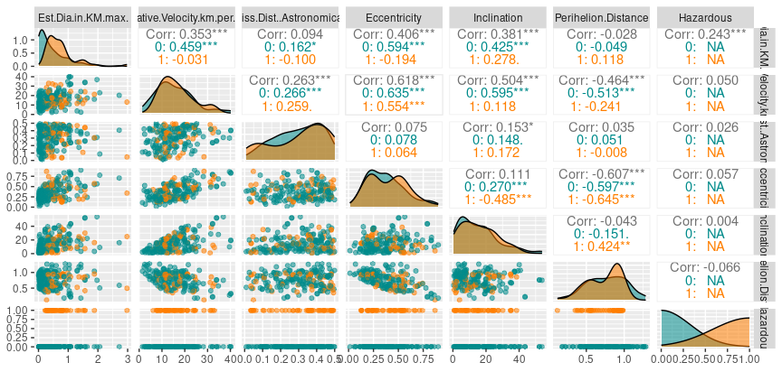

Una volta addestrati i modelli viene scelto il modello migliore sulla base del parametro “Baesyan Information Criterion” (BIC), un criterio di selezione che preferisce modelli con pochi parametri e più facilmente interpretabili. Questa misura infatti tiene conto sia della precisione del modello sia del numero di parametri utilizzati. In generale si cerca di minimizzare il valore di BIC, ma la libreria MoEClust utilizza la definizione di BIC della libreria mcclust, che lo definisce come il negativo del valore BIC originale. Verrà selezionato quindi il modello con il valore BIC più alto.

```r
# Confronto tra modelli custom e modelli addestrati tramite ricerca greedy
custom <- MoE_compare(model_1, model_2, model_3, model_4, optimal.only = FALSE)
stepwise <- MoE_compare(optimized_models, optimal.only = FALSE)

plot(MoE_compare(custom, stepwise, optimal.only = FALSE), what="criterion")
```

[output not shown]

```r
# Scelta del modello ottimale
best <- MoE_compare(custom, stepwise, optimal.only = FALSE)$optimal
summary(best)
```

```
Best model occurs at the max of the number of components considered
```

```
------------------------------------------------------
Gaussian Parsimonious Clustering Model with Covariates
Data: clustering_dataset
------------------------------------------------------

MoEClust: VVV (ellipsoidal, varying volume, shape, and orientation), with 4 components

Gating Network Covariates:  ~Hazardous + Absolute.Magnitude + Jupiter.Tisserand.Invariant
Expert Network Covariates:  None
Noise Component:            FALSE
```

| log.likelihood | n | d | df | iters | BIC | ICL | AIC | Algo |
| --- | --- | --- | --- | --- | --- | --- | --- | --- |
| 31109.51 | 1500 | 13 | 428 | 2 | 59088.95 | 59052.01 | 61363.01 | EM |

```
Clustering table :
  1   2   3   4
184 410 278 628
```

```r
# Risultati del clustering su coppie di feature
plot(best, what="gpairs")
```

[output not shown]

```r
# Visualizzazione clustering
data <- list(data = clustering_dataset, cluster=predict(best, clustering_dataset)$classification)
fviz_cluster(data, ellipse.type = "norm")
```

[output not shown]

I risultati del clustering sono quindi precisi nel raggruppare gli asteroidi in gruppi che corrispondono ad una classificazione effettivamente utilizzata nel loro campo di studio. Questo tipo di risultato può essere utile non solo per effettuare un filtering iniziale degli asteroidi ma anche per effettuare predizioni sulla probabile tipologia dell’asteroide anche in contesti di informazioni mancanti. La libreria MoEClust infatti permette di effettuare predizioni anche in caso di feature mancanti.

Un possibile sviluppo futuro potrebbe essere il confronto dei risultati ottenuti con algoritmi di clustering basati su distanza oppure effettuare classificazione della pericolosità degli asteroidi utilizzando come informazione anche la presenza dell’asteroide in uno dei cluster trovati.